# Stat 415 Regression: Test 1

Frankie Tyndall

2022-07-14

## Part 1: Dataset

```r
x_y_data <- tribble(~X,  ~Y,
         221  ,                 33,
         400  ,                 42,
         300  ,                 37,
         400  ,                 53,
         200  ,                 22,
         260  ,                 37,
         300  ,                 40,
         375  ,                 42,
         210  ,                 25,
         400  ,                 52,
         200  ,                 30,
         344  ,                 42,
  )

x_y_data
```

```
## # A tibble: 12 × 2
##        X     Y
##    <dbl> <dbl>
##  1   221    33
##  2   400    42
##  3   300    37
##  4   400    53
##  5   200    22
##  6   260    37
##  7   300    40
##  8   375    42
##  9   210    25
## 10   400    52
## 11   200    30
## 12   344    42
```

## 1a: Use and show R code to produce a scatter plot for the bivariate data given above. Indicate if the scatter plot is showing a definitive positive or negative trend for the data.

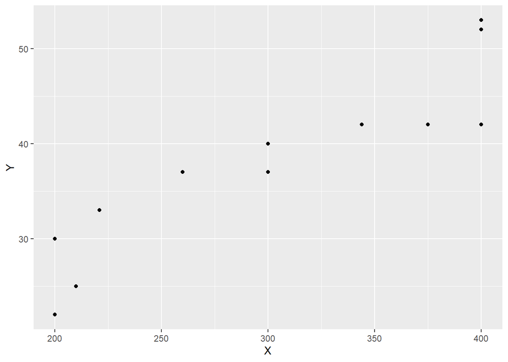

```r
qplot(x = X, y = Y , data = x_y_data, geom = "point")
```

The scatter plot is showing a strong positive trend/relationship between the X and Y variables.

## 1b: Use and show R code to produce a linear model for the bivariate data shown above. Interpret the slope of your model.

```r
lm(x_y_data$Y ~ x_y_data$X)
```

```
##
## Call:
## lm(formula = x_y_data$Y ~ x_y_data$X)
##
## Coefficients:
## (Intercept)   x_y_data$X
##      6.0631       0.1059
```

slope = 0.1059 y intercept = 6.0631

y(hat) = 6.0631 + 0.1059x

## Use and show R code to determine how much of the variation in Y is explained by your model.

```r
summary(lm(x_y_data$Y ~ x_y_data$X))
```

```
##
## Call:
## lm(formula = x_y_data$Y ~ x_y_data$X)
##
## Residuals:
##     Min      1Q  Median      3Q     Max
## -6.4169 -3.4166  0.8421  3.4393  4.5831
##
## Coefficients:
##             Estimate Std. Error t value Pr(>|t|)
## (Intercept)  6.06311    4.65678   1.302    0.222
## x_y_data$X   0.10588    0.01498   7.068 3.42e-05 ***
## ---
## Signif. codes:  0 '***' 0.001 '**' 0.01 '*' 0.05 '.' 0.1 ' ' 1
##
## Residual standard error: 4.061 on 10 degrees of freedom
## Multiple R-squared:  0.8332, Adjusted R-squared:  0.8165
## F-statistic: 49.96 on 1 and 10 DF,  p-value: 3.424e-05
```

the R-squared value is 0.8332. This means that 83.32% of the variation in Y is explained by the regression model with X

## Find a 95% confidence interval for the slope of your model.

```r
slope_conf <- lm(x_y_data$Y ~ x_y_data$X)

confint(slope_conf, '(Intercept)', level=0.95)
```

```
##                 2.5 %   97.5 %
## (Intercept) -4.312842 16.43906
```

```r
confint(slope_conf, 'x_y_data$X', level=0.95)
```

```
##                 2.5 %    97.5 %
## x_y_data$X 0.07250468 0.1392641
```

```r
# the code from class was not working, so I found the answer this way
```

We are 95% confident that the true population slope falls between 0.07250468 and 0.1392641

## Using the Bonferroni method illustrated in class, find simultaneous confidence intervals for the intercept and the slope of your model. 90%

## confidence interval

```r
joint_conf <- summary(lm(x_y_data$Y ~ x_y_data$X))
joint_conf
```

```
##
## Call:
## lm(formula = x_y_data$Y ~ x_y_data$X)
##
## Residuals:
##     Min      1Q  Median      3Q     Max
## -6.4169 -3.4166  0.8421  3.4393  4.5831
##
## Coefficients:
##             Estimate Std. Error t value Pr(>|t|)
## (Intercept)  6.06311    4.65678   1.302    0.222
## x_y_data$X   0.10588    0.01498   7.068 3.42e-05 ***
## ---
## Signif. codes:  0 '***' 0.001 '**' 0.01 '*' 0.05 '.' 0.1 ' ' 1
##
## Residual standard error: 4.061 on 10 degrees of freedom
## Multiple R-squared:  0.8332, Adjusted R-squared:  0.8165
## F-statistic: 49.96 on 1 and 10 DF,  p-value: 3.424e-05
```

b1 = 0.10588 standard error of b1 = 0.01498

b0 = 6.06311 standard error of b1 = 4.65678

Interval for B1 = 0.10588 +/- 2.22814(0.01498) = 0.0725 <= B1 <= 0.13925 Interval for Bo = 6.06311 +/- 2.22814(4.65678 ) = -4.31 <= B0 <= 16.439

## Find the specific residual for the data point (400,42). Does the residual indicate that the observed value of 400 is above or below average. Explain why or why not.

```r
observed_Y_42 <- x_y_data %>%
  filter(X == 400 & Y == 42)

observed_Y_42
```

```
## # A tibble: 1 × 2
##       X     Y
##   <dbl> <dbl>
## 1   400    42
```

y(hat) = 6.0631 + 0.1059x y(hat) = 6.0631 + 0.1059(400) y(hat) = expected value = 48.4231

residual = observed - expected residual = 42 - 48.4231 = -6.4231

The residual of -6.4231 indicates that the observed value of 400 which is 42 is below average. The residual is negative which indicates that the observed values is below average.

## Use and show R code to find all of the residuals of your model.

```r
model_xy <- lm(Y~X, data = x_y_data)
residual_model <- resid(model_xy)
residual_model
```

```
##          1          2          3          4          5          6          7
##  3.5364385 -6.4168704 -0.8284297  4.5831296 -5.2399889  3.4069466  2.1715703
##          8          9         10         11         12
## -3.7697602 -3.2988330  3.5831296  2.7600111 -0.4873436
```

## Use and show R code to produce the residual plot. (Residuals versus Fitted Values) Does the Residual Plot suggest a good linear fit for your model? Explain why or why not.

```r
model_xy <- lm(Y~X, data = x_y_data)
residual_model <- resid(model_xy)
residual_model
```

```
##          1          2          3          4          5          6          7
##  3.5364385 -6.4168704 -0.8284297  4.5831296 -5.2399889  3.4069466  2.1715703
##          8          9         10         11         12
## -3.7697602 -3.2988330  3.5831296  2.7600111 -0.4873436
```

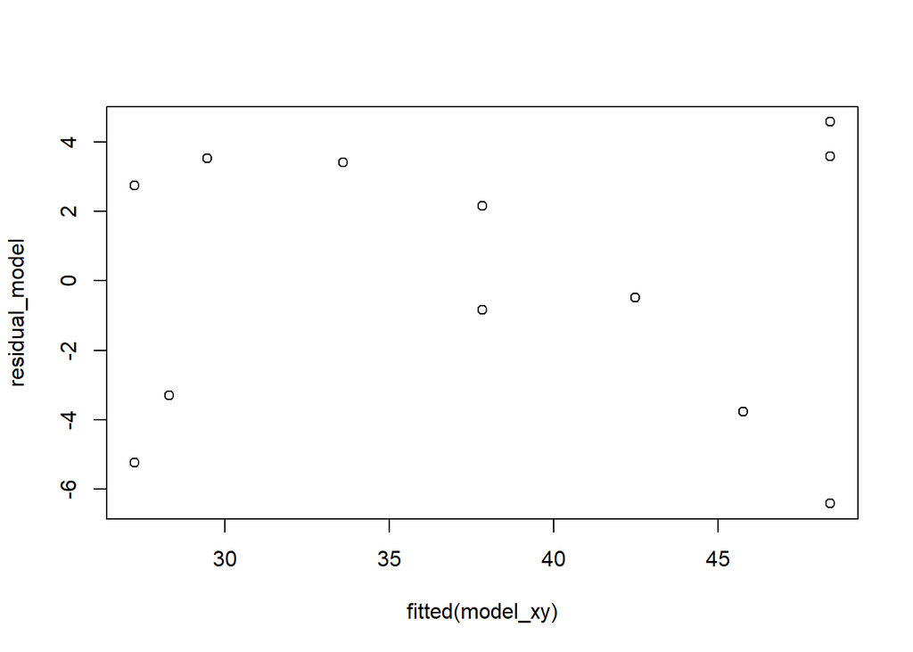

```r
plot(fitted(model_xy), residual_model)
```

The residual plot does suggest a linear relationship between X and Y because the residuals “bounce randomly” around the 0 line with no distinct pattern shown.

## Use and show R code that produces a boxplot of your residuals. Does your boxplot indicate the existence of outliers.

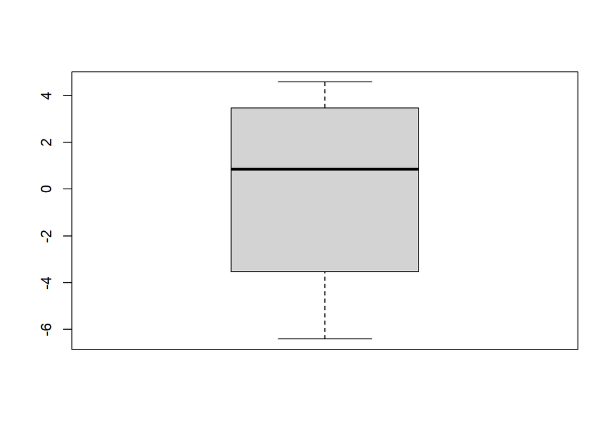

```r
boxplot(residual_model)
```

The boxplot does not suggest the existence of an outlier in the data. There is no outlier that stands out from the basic pattern of residuals.

## Use and show R code to determine the normality status of your residuals.

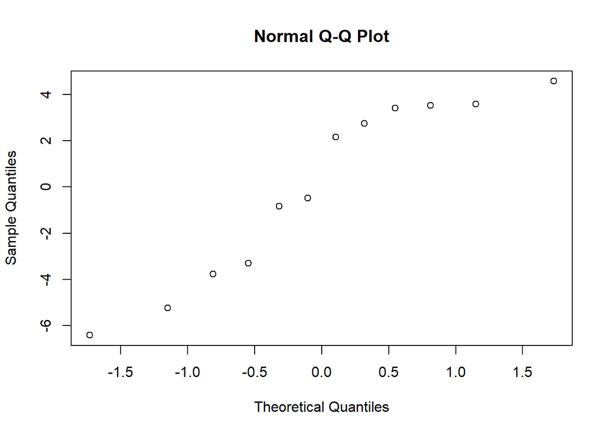

```r
qqnorm(residual_model)
```

The residuals are normally distributed as the data appears to roughly be a straight line.

## Find the value that estimates the variance of the population linear model. (Use may use R)

```r
pp <- x_y_data
anova(lm(pp$Y ~ pp$X))
```

```
## Analysis of Variance Table
##
## Response: pp$Y
##           Df Sum Sq Mean Sq F value    Pr(>F)
## pp$X       1 823.97  823.97  49.956 3.424e-05 ***
## Residuals 10 164.94   16.49
## ---
## Signif. codes:  0 '***' 0.001 '**' 0.01 '*' 0.05 '.' 0.1 ' ' 1
```

The estimated variance of the population linear model is 16.49

## Execute an F test in order to determine if a linear model is appropriate.Use the steps and procedure illustrated in class by making use of an ANOVA table, the F value, and the F critical number. And of course, indicate if the null hypothesis should be rejected.

```r
pp_f <- lm(Y~X, data = x_y_data)
anova(pp_f)
```

```
## Analysis of Variance Table
##
## Response: Y
##           Df Sum Sq Mean Sq F value    Pr(>F)
## X          1 823.97  823.97  49.956 3.424e-05 ***
## Residuals 10 164.94   16.49
## ---
## Signif. codes:  0 '***' 0.001 '**' 0.01 '*' 0.05 '.' 0.1 ' ' 1
```

```r
qf(p=.05, df1=1, df2=10, lower.tail=FALSE)
```

```
## [1] 4.964603
```

The F value of 49.956 is greater than the F critical value of 4.964603. We will reject the null hypothesis that B1 = 0. This means that a linear relationship does exist between the X and Y variables

## Part 2: Dataset

```r
Scatter_xi_yi <- tribble(~Xi,  ~Yi,
           0  ,                 98,
           1  ,                135,
           2  ,                162,
           3  ,                178,
           4  ,                221,
           5  ,                232,
           6  ,                283,
           7  ,                300,
           8  ,                374,
           9  ,                395,

  )

Scatter_xi_yi
```

```
## # A tibble: 10 × 2
##       Xi    Yi
##    <dbl> <dbl>
##  1     0    98
##  2     1   135
##  3     2   162
##  4     3   178
##  5     4   221
##  6     5   232
##  7     6   283
##  8     7   300
##  9     8   374
## 10     9   395
```

## Prepare a scatter plot of the data. Does a linear relation appear to be appropriate.

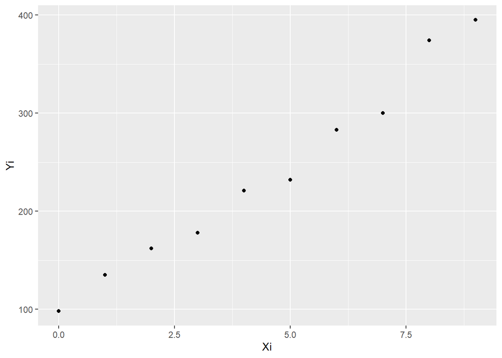

```r
qplot(x = Xi, y = Yi, data = Scatter_xi_yi, geom = "point")
```

The scatter plot suggest that a linear relation does seem appropriate